# Effects of Medicaid on Clinical Outcomes

Author

Damini, Yoobee & Sathwik

Git Hub Repo:https://github.com/sathwik-bollepalli/STAT5125_Final_Project

# IMPACT OF MEDICAID COVERAGE ON PHYSICAL AND MENTAL HEALTH

# **Abstract**

This study leverages a comprehensive dataset from the Oregon Health Insurance Experiment to develop a predictive model assessing the impact of Medicaid expansion on healthcare utilization and mental health outcomes. By analyzing variables from in-person interviews, surveys, state program participation, healthcare patterns, emergency department visits, and more, we aim to identify key predictors of mental health improvements and healthcare service usage among Medicaid beneficiaries. The predictive model seeks to offer actionable insights for healthcare providers and policymakers to optimize health insurance programs for improved mental health support and efficient healthcare service utilization.

# **Introduction**:

The relationship between health insurance coverage, specifically Medicaid expansion, and health outcomes remains a pivotal area of inquiry in health economics and public policy. The Oregon Health Insurance Experiment, a landmark study initiated through a unique lottery system for Medicaid enrollment, provides a valuable dataset for exploring this relationship further. Our study proposes to utilize machine learning techniques to analyze the dataset, focusing on predicting healthcare utilization patterns and mental health outcomes among participants. By doing so, we aim to contribute to the ongoing discourse on the efficacy of health insurance expansion as a tool for public health improvement.

# **Goal**

We aim to develop a machine learning model that predicts the impact of health insurance coverage on mental and/or physical health improvements.

# **Data Description**:

Key features of the dataset include:

- Blood pressure, cholesterol levels, glycated hemoglobin measurements
- Depression screening outcomes
- Medication inventories
- Self-reported health diagnoses
- Healthcare utilization data
- Out-of-pocket spending

The data was collected from two groups:

1. 6,387 adults who were offered Medicaid enrollment (“lottery winners”)
2. 5,842 adults who were not offered Medicaid (“control group”)

Additionally, the data collection involved in-person interviews, health assessments, and surveys conducted within the Portland metropolitan area.

Overall, this unique dataset from a randomized controlled trial provides valuable opportunities to analyze the impact of Medicaid coverage on various health outcomes and healthcare utilization patterns.

# Data Import

Importing Required Libraries

```r
library(tidyr)
library(ggplot2)
library(tidyverse)
library(dplyr)
library(visdat)
library(naniar)
library(tidymodels)
library(klaR)
library(discrim)
library(yardstick)
theme_set(theme_bw())
```

```r
oregon_patterns <- read.csv("data/oregonhie_patterns_vars.csv")
oregon_descriptive <- read.csv("data/oregonhie_descriptive_vars.csv")
oregon_in_person <- read.csv("data/oregonhie_inperson_vars.csv")
oregon_emergency <- read.csv("data/oregonhie_ed_vars.csv")
oregon_survey_0m <- read.csv("data/oregonhie_survey0m_vars.csv")
oregon_survey_6m <- read.csv("data/oregonhie_survey6m_vars.csv")
oregon_survey_12m <- read.csv("data/oregonhie_survey12m_vars.csv")
```

```r
dim(oregon_patterns)
```

```
[1] 24646    36
```

```r
dim(oregon_descriptive)
```

```
[1] 74922    23
```

```r
dim(oregon_in_person)
```

```
[1] 20745    90
```

```r
dim(oregon_emergency)
```

```
[1] 24646    89
```

```r
dim(oregon_survey_6m)
```

```
[1] 74922   134
```

```r
dim(oregon_survey_12m)
```

```
[1] 74922   151
```

Checking for Duplicate Values

```r
 tables <- list(
   oregon_survey_12m = oregon_survey_12m,
   oregon_survey_6m = oregon_survey_6m,
   oregon_survey_0m = oregon_survey_0m,
   oregon_emergency = oregon_emergency,
   oregon_in_person = oregon_in_person,
   oregon_descriptive = oregon_descriptive,
   oregon_patterns = oregon_patterns
 )

 for (table_name in names(tables)) {
   data <- tables[[table_name]]
   has_duplicates <- anyDuplicated(data$person_id) > 0
   has_nulls <- any(is.na(data$person_id))

   print(table_name)
   if (has_duplicates) {
     print("has duplicates")
   } else {
     print("no duplicates")
   }

   if (has_nulls) {
     print("has null values in person_id.")
   } else {
     print("no null values in person_id.")
   }
   print("---------------------")
 }
```

```
[1] "oregon_survey_12m"
[1] "no duplicates"
[1] "no null values in person_id."
[1] "---------------------"
[1] "oregon_survey_6m"
[1] "no duplicates"
[1] "no null values in person_id."
[1] "---------------------"
[1] "oregon_survey_0m"
[1] "no duplicates"
[1] "no null values in person_id."
[1] "---------------------"
[1] "oregon_emergency"
[1] "no duplicates"
[1] "no null values in person_id."
[1] "---------------------"
[1] "oregon_in_person"
[1] "no duplicates"
[1] "no null values in person_id."
[1] "---------------------"
[1] "oregon_descriptive"
[1] "no duplicates"
[1] "no null values in person_id."
[1] "---------------------"
[1] "oregon_patterns"
[1] "no duplicates"
[1] "no null values in person_id."
[1] "---------------------"
```

# Data cleaning

For data cleaning, we implemented several steps to ensure the quality of our dataset. Initially, we developed a **custom function** tailored to convert data into a usable format and then employed various **imputation techniques** such as regression to fill in the gaps of missing data. Subsequently, we conducted a thorough data cleansing process, leveraging **regular expressions** to identify and correct any inconsistencies or errors present in the dataset, especially when dealing with strings to convert them into binary ensuring uniformity and accuracy across all records.

## 1. oregon_in_person dataset

check non-numeric values

```r
non_numeric_columns <- names(oregon_in_person)[sapply(oregon_in_person, function(x) !is.numeric(x))]

unique_non_numeric_values <- lapply(oregon_in_person[non_numeric_columns], function(x) unique(x))

for (i in seq_along(non_numeric_columns)) {
  cat("Column:", non_numeric_columns[i], "\n")
  print(unique_non_numeric_values[[i]])
  cat("\n")
}
```

```
Column: in_data_inp
[1] "Yes"

Column: sample_resp_inp
[1] "Non Respondent" "Respondent"

Column: dt_release_inp
 [1] "2010-05-17" "2009-11-30" "2010-03-09" "2010-01-13" ""
 [6] "2009-09-23" "2010-06-02" "2010-03-15" "2010-03-30" "2009-09-09"
[11] "2010-06-09" "2010-02-22" "2009-10-29" "2010-01-20" "2010-07-12"
[16] "2010-04-08" "2010-04-12" "2010-04-19" "2009-11-20" "2010-03-23"
[21] "2010-07-20" "2010-08-10" "2010-02-08" "2009-12-07" "2010-07-06"
[26] "2009-10-15" "2009-12-14" "2010-02-15" "2009-12-30" "2010-02-02"
[31] "2009-11-05" "2010-06-21" "2009-12-28" "2010-06-14" "2010-05-04"
[36] "2010-08-04" "2009-08-31" "2009-11-12" "2010-06-29" "2009-10-22"
[41] "2010-04-26" "2010-01-25"

Column: dt_completed_inp
  [1] ""           "2009-12-15" "2010-04-07" "2010-01-19" "2009-10-05"
  [6] "2010-06-03" "2009-09-23" "2010-07-15" "2010-03-06" "2009-11-25"
 [11] "2010-01-30" "2010-02-18" "2009-08-25" "2010-07-28" "2010-04-30"
 [16] "2010-06-18" "2010-08-05" "2010-09-17" "2010-04-27" "2010-01-18"
 [21] "2010-02-11" "2009-12-31" "2009-08-24" "2010-08-16" "2010-04-21"
 [26] "2010-09-21" "2009-10-30" "2010-05-28" "2010-04-20" "2010-06-01"
 [31] "2010-06-22" "2010-01-20" "2009-10-14" "2010-08-17" "2010-07-22"
 [36] "2010-05-10" "2010-07-08" "2009-12-16" "2010-01-29" "2010-07-31"
 [41] "2010-04-18" "2009-10-20" "2010-01-13" "2010-02-10" "2010-05-27"
 [46] "2009-11-17" "2010-06-29" "2010-01-15" "2010-08-23" "2009-09-29"
 [51] "2010-03-24" "2009-09-28" "2010-05-03" "2010-06-17" "2010-08-18"
 [56] "2010-08-27" "2010-07-16" "2010-05-12" "2010-03-18" "2010-09-04"
 [61] "2010-06-23" "2009-10-17" "2009-12-29" "2009-11-19" "2010-07-24"
 [66] "2010-05-26" "2010-07-25" "2010-09-18" "2010-05-20" "2009-11-12"
 [71] "2010-04-15" "2009-10-22" "2010-08-02" "2010-09-03" "2010-09-12"
 [76] "2010-08-15" "2010-08-10" "2010-08-13" "2010-02-05" "2010-04-01"
 [81] "2010-04-08" "2010-01-31" "2009-10-06" "2010-06-12" "2009-11-18"
 [86] "2010-03-25" "2010-08-31" "2010-03-15" "2010-04-16" "2010-09-14"
 [91] "2010-08-11" "2010-09-09" "2010-09-30" "2010-07-23" "2009-10-19"
 [96] "2009-11-24" "2010-06-16" "2009-09-27" "2010-09-08" "2009-09-13"
[101] "2010-09-11" "2009-12-04" "2009-12-17" "2009-09-21" "2010-08-21"
[106] "2009-11-29" "2010-06-26" "2010-04-06" "2009-11-23" "2010-07-29"
```

[output cut: 257 more lines]

```

Column: hbp_diure_med_inp
[1] ""    "No"  "Yes"

Column: antihyperlip_med_inp
[1] ""    "No"  "Yes"

Column: diabetes_med_inp
[1] ""    "No"  "Yes"

Column: antidep_med_inp
[1] ""    "No"  "Yes"

Column: meds_miss_inp
[1] ""    "No"  "Yes"
```

1. Change “Yes”, “No” to 1, 0

```r
# Replace "Yes" with 1 and "No" with 0
non_numeric_cols <- names(oregon_in_person)[sapply(oregon_in_person, function(x) !is.numeric(x))]

for (col in non_numeric_cols) {
  oregon_in_person[[col]] <- ifelse(oregon_in_person[[col]] == "Yes", 1,
                                    ifelse(oregon_in_person[[col]] == "No", 0, oregon_in_person[[col]]))
}
```

2. change values that looks like “(integer): (description)” to coresponding integer

```r
cols_to_clean <- names(oregon_in_person)[sapply(oregon_in_person, function(x) any(grepl("\\d+: ", x)))]

for (col in cols_to_clean) {
  oregon_in_person[[col]] <- gsub("^(\\d+):.*", "\\1", oregon_in_person[[col]])
}

oregon_in_person[cols_to_clean] <- lapply(oregon_in_person[cols_to_clean], as.numeric)

# Check
for (col in cols_to_clean) {
  unique_values <- unique(oregon_in_person[[col]])
  cat("Unique values in", col, ":\n")
  print(unique_values)
  cat("\n")
}
```

```
Unique values in interview_location_inp :
[1] NA  2  1  4  3

Unique values in health_last12_inp :
[1] NA  4  5  3  2  6  1

Unique values in health_change_inp :
[1] NA  1  2  0

Unique values in sf4_inp :
[1] NA  1  0  3  2  4  5

Unique values in happiness_inp :
[1] NA  0  1  2

Unique values in med_qual_inp :
[1] NA  2  5  0  4  1  3

Unique values in smk_curr_inp :
[1] NA  1  2  0
```

3. Change “Respondent”, “Non Respondent” to 1, 0

```r
# 0, 1 : non, res

unique(oregon_in_person$sample_resp_inp)
```

```
[1] "Non Respondent" "Respondent"
```

```r
col <- 'sample_resp_inp'

oregon_in_person[[col]] <- ifelse(oregon_in_person[[col]] == "Respondent", 1,
                                    ifelse(oregon_in_person[[col]] == "Non Respondent", 0, oregon_in_person[[col]]))

unique(oregon_in_person$sample_resp_inp)
```

```
[1] "0" "1"
```

4. Language_inp (Language of survey) - Mutate the data using one-hot encoding

```r
# dummy
unique(oregon_in_person$language_inp)
```

```
[1] ""        "English" "Spanish"
```

```r
#one-hot encoding
encoded_language <- model.matrix(~ language_inp - 1, data = oregon_in_person)

colnames(encoded_language) <- gsub("^language_inp", "", colnames(encoded_language))

oregon_in_person <- cbind(oregon_in_person, encoded_language)

#check
unique(oregon_in_person$English)
```

```
[1] 0 1
```

```r
unique(oregon_in_person$Spanish)
```

```
[1] 0 1
```

```r
unique(oregon_in_person$language_inp)
```

```
[1] ""        "English" "Spanish"
```

```r
oregon_in_person <- subset(oregon_in_person, select = -c(language_inp))
```

5. gender_inp, edu_inp: mapping

```r
# male: 0 to f to m: 4
unique(oregon_in_person$gender_inp)
```

```
[1] ""                    "Female"              "Male"
[4] "Transgender F to M"  "Transgender: M to F"
```

```r
gender_mapping <- c("Female" = 1,
                    "Male" = 0,
                    "Transgender F to M" = 0,
                    "Transgender: M to F" = 1)

oregon_in_person$gender_inp <- gender_mapping[oregon_in_person$gender_inp]

unique_values <- unique(oregon_in_person$gender_inp)
cat("Unique values in gender_inp:\n")
```

```
Unique values in gender_inp:
```

```r
print(unique_values)
```

```
[1] NA  1  0
```

```r
# order 1 to 4
unique(oregon_in_person$edu_inp)
```

```
[1] ""                      "4 year degree or more" "HS diploma or GED"
[4] "Post HS, not 4-year"   "Less than HS"
```

```r
education_mapping <- c(
                        "Less than HS" = 1,
                        "HS diploma or GED" = 2,
                        "Post HS, not 4-year" = 3,
                        "4 year degree or more" = 4)

oregon_in_person$edu_inp <- education_mapping[oregon_in_person$edu_inp]

unique_values <- unique(oregon_in_person$edu_inp)
cat("Unique values in edu_inp:\n")
```

```
Unique values in edu_inp:
```

```r
print(unique_values)
```

```
[1] NA  4  2  3  1
```

6. scale_id_inp (ID of Scale used to measure weight), stadio_id_inp (ID of Stadiometer used to measure height), omron_id_inp (ID of equipment used to measure blood pressure)  
   We could map the data using ID categories, but these values seems hard to interpret, seems not meaningful for analysis. So we decide to drop it.

```r
 list_id_inp <- c("scale_id_inp", "stadio_id_inp", "omron_id_inp")

 for (col in list_id_inp) {
   missing_count <- sum(oregon_in_person[[col]] == "")
   cat("Number of missing values in", col, ":", missing_count, "\n")
 }
```

```
Number of missing values in scale_id_inp : 8543
Number of missing values in stadio_id_inp : 8534
Number of missing values in omron_id_inp : 8556
```

```r
oregon_in_person <- subset(oregon_in_person, select = -c(scale_id_inp, stadio_id_inp, omron_id_inp))
```

7. Dealing with datetime data: dt_release_inp, dt_completed_inp  
   Convert the data to datetime objects and extract components (day, month and year)

```r
oregon_in_person$dt_release_inp <- ymd(oregon_in_person$dt_release_inp)
oregon_in_person$dt_completed_inp <- ymd(oregon_in_person$dt_completed_inp)

oregon_in_person$release_year <- year(oregon_in_person$dt_release_inp)
oregon_in_person$release_month <- month(oregon_in_person$dt_release_inp)
oregon_in_person$release_day <- day(oregon_in_person$dt_release_inp)

oregon_in_person$completed_year <- year(oregon_in_person$dt_completed_inp)
oregon_in_person$completed_month <- month(oregon_in_person$dt_completed_inp)
oregon_in_person$completed_day <- day(oregon_in_person$dt_completed_inp)

#drop dt_
oregon_in_person <- subset(oregon_in_person, select = -c(dt_release_inp, dt_completed_inp))
```

Converting 0,1 as numeric; few are stored as string

```r
#to numeric
non_numeric_columns <- names(oregon_in_person)[sapply(oregon_in_person, function(x) !is.numeric(x))]

oregon_in_person <- oregon_in_person |>
  mutate_at(vars(non_numeric_columns), as.numeric)
```

**check**

```r
#check
non_numeric_columns <- names(oregon_in_person)[sapply(oregon_in_person, function(x) !is.numeric(x))]

unique_non_numeric_values <- lapply(oregon_in_person[non_numeric_columns], function(x) unique(x))

for (i in seq_along(non_numeric_columns)) {
  cat("Column:", non_numeric_columns[i], "\n")
  print(unique_non_numeric_values[[i]])
  cat("\n")
}
```

#### Dealing with missing values

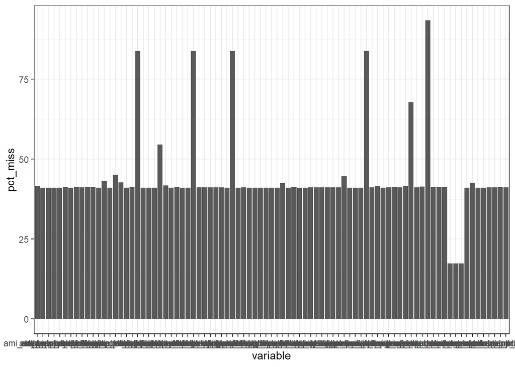

```r
oregon_in_person |>
  miss_var_summary()|>
  filter(n_miss>0)|>
  ggplot(aes(variable,pct_miss))+
  geom_bar(stat = "identity")
```

```r
missing_percentage <- rowMeans(is.na(oregon_in_person))

threshold <- 0.8
complete_rows <- missing_percentage < threshold
oregon_in_person_complete <- oregon_in_person[complete_rows, ]

dim(oregon_in_person_complete)
```

```
[1] 12229    93
```

```r
missing_col <- colMeans(is.na(oregon_in_person_complete))

complete_cols <- missing_col < 0.2

oregon_in_person_complete <- oregon_in_person_complete[,complete_cols]

dim(oregon_in_person_complete)
```

```
[1] 12229    86
```

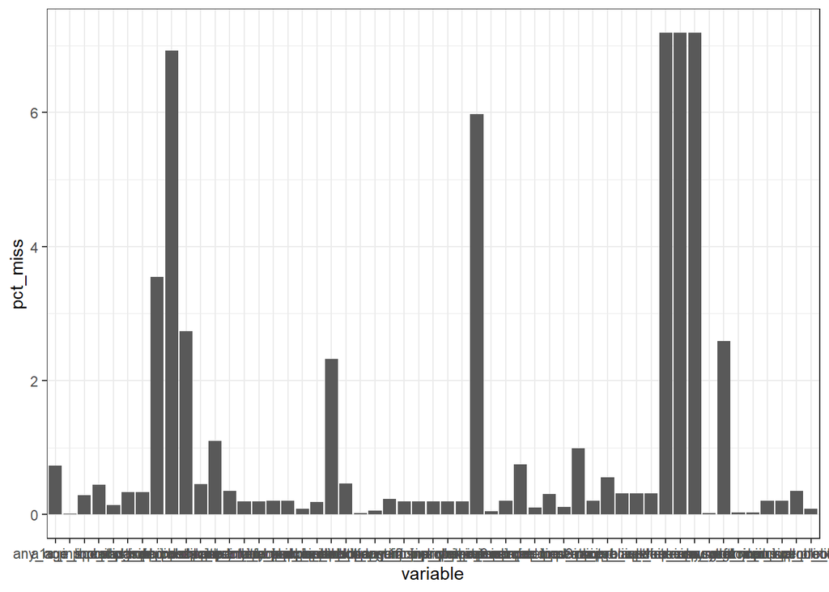

```r
oregon_in_person_complete |>
  miss_var_summary()|>
  filter(n_miss>0)|>
  ggplot(aes(variable,pct_miss))+
  geom_bar(stat = "identity")
```

```r
missing_col <- colSums(is.na(oregon_in_person_complete))
# print(missing_col)

columns_with_missing <- names(oregon_in_person_complete)[colSums(is.na(oregon_in_person_complete)) > 0]

# Step 2: Check the unique values in each of these columns
for (col in columns_with_missing) {
  unique_values <- unique(oregon_in_person_complete[[col]])
  cat("Column:", col, "\n")
  # print(unique_values)
  # cat("\n")
}
```

```
Column: interviewer_inp
Column: interpreter_inp
Column: age_inp
Column: health_last12_inp
Column: health_change_inp
Column: sf4_inp
Column: dia_dx_post_lottery_inp
Column: hbp_dx_post_lottery_inp
Column: chl_dx_post_lottery_inp
Column: dep_dx_post_lottery_inp
Column: happiness_inp
Column: phqtot_inp
Column: pcs8_score_inp
Column: mcs8_score_inp
Column: usual_clinic_inp
Column: needmet_med_inp
Column: needmet_ment_inp
Column: needmet_rx_inp
Column: med_qual_inp
Column: chl_chk_inp
Column: smk_curr_inp
Column: doc_num_incl_probe_inp
Column: doc_any_incl_probe_inp
Column: ed_num_incl_probe_inp
Column: ed_any_incl_probe_inp
Column: surg_num_incl_probe_inp
Column: surg_any_incl_probe_inp
Column: hosp_num_incl_probe_inp
Column: hosp_any_incl_probe_inp
Column: tot_med_spend_other_inp
Column: any_oop_spending_inp
Column: catastrophic_exp_inp
Column: ins_any_inp
Column: ins_ohp_inp
Column: ins_private_inp
Column: owe_inp
Column: borrow_inp
Column: edu_inp
Column: hispanic_inp
Column: race_white_inp
Column: race_black_inp
Column: race_nwother_inp
Column: a1c_inp
Column: hdl_inp
Column: chl_inp
Column: bmi_inp
Column: bp_sar_inp
Column: bp_dar_inp
Column: rx_any_mod_inp
Column: rx_num_mod_inp
Column: release_year
Column: release_month
Column: release_day
```

- binary columns - fill missing values with 0

```r
non_binary_columns <- character(0)
binary_columns <- character(0)

columns_with_missing <- names(oregon_in_person_complete)[colSums(is.na(oregon_in_person_complete)) > 0]

for (col in columns_with_missing) {
  unique_values <- unique(oregon_in_person_complete[[col]])
  num_unique <- length(unique_values)
  if (num_unique == 3) {
    binary_columns <- c(binary_columns, col)
  } else {
    non_binary_columns <- c(non_binary_columns, col)
  }
}
```

```r
oregon_in_person_complete[binary_columns][is.na(oregon_in_person_complete[binary_columns])] <- 0
```

- Binary target columns - drop row that have NA values in target columns

```r
sum(is.na(oregon_in_person_complete$happiness_inp))
```

```
[1] 23
```

```r
sum(is.na(oregon_in_person_complete$health_change_inp))
```

```
[1] 3
```

```r
oregon_in_person_complete <- oregon_in_person_complete[complete.cases(oregon_in_person_complete$happiness_inp, oregon_in_person_complete$health_change_inp), ]

sum(is.na(oregon_in_person_complete$happiness_inp))
```

```
[1] 0
```

```r
sum(is.na(oregon_in_person_complete$health_change_inp))
```

```
[1] 0
```

- Non binary - to median

```r
impute_median <- function(x) {
  median_value <- median(x, na.rm = TRUE)
  x[is.na(x)] <- median_value
  return(x)
}

for (col in non_binary_columns) {
  if (is.numeric(oregon_in_person_complete[[col]]) && length(unique(oregon_in_person_complete[[col]])) > 2) {
    oregon_in_person_complete[[col]] <- impute_median(oregon_in_person_complete[[col]])
  }
}
```

```r
#non-numeric values
non_numeric_columns <- names(oregon_descriptive)[sapply(oregon_descriptive, function(x) !is.numeric(x))]

unique_non_numeric_values <- lapply(oregon_descriptive[non_numeric_columns], function(x) unique(x))

for (i in seq_along(non_numeric_columns)) {
  cat("Column:", non_numeric_columns[i], "\n")
  print(unique_non_numeric_values[[i]])
  cat("\n")
}
```

```
Column: treatment
[1] "Selected"     "Not selected"

Column: draw_treat
[1] "Draw 7: selected in lottery 08/01/2008"
[2] "Draw 6: selected in lottery 07/01/2008"
[3] ""
[4] "Draw 3: selected in lottery 04/08/2008"
[5] "Draw 2: selected in lottery 03/27/2008"
[6] "Draw 8: selected in lottery 09/02/2008"
[7] "Draw 1: selected in lottery 03/05/2008"
[8] "Draw 4: selected in lottery 05/01/2008"
[9] "Draw 5: selected in lottery 06/02/2008"

Column: draw_lottery
```

[output cut: 103 more lines]

#### Mutating

1. mapping

```r
non_numeric_cols <- names(oregon_descriptive)[sapply(oregon_descriptive, function(x) !is.numeric(x))]

for (col in non_numeric_cols) {
  # "Yes", "No"
  oregon_descriptive[[col]] <- ifelse(oregon_descriptive[[col]] == "Yes", 1,
                                    ifelse(oregon_descriptive[[col]] == "No", 0, oregon_descriptive[[col]]))

  #"Selected", "Not selected"
  oregon_descriptive[[col]] <- ifelse(oregon_descriptive[[col]] == "Selected", 1,
                                    ifelse(oregon_descriptive[[col]] == "Not selected", 0, oregon_descriptive[[col]]))

  #"Submitted an Application to OHP", "Did NOT submit an application to OHP"
  oregon_descriptive[[col]] <- ifelse(oregon_descriptive[[col]] == "Submitted an Application to OHP", 1,
                                    ifelse(oregon_descriptive[[col]] == "Did NOT submit an application to OHP", 0, oregon_descriptive[[col]]))

  #"Alive" "Dead"
  oregon_descriptive[[col]] <- ifelse(oregon_descriptive[[col]] == "Dead", 1,
                                    ifelse(oregon_descriptive[[col]] == "Alive", 0, oregon_descriptive[[col]]))

  #"Gave Phone Number", "Did NOT give phone number"
  oregon_descriptive[[col]] <- ifelse(oregon_descriptive[[col]] == "Gave Phone Number", 1,
                                    ifelse(oregon_descriptive[[col]] == "Did NOT give phone number", 0, oregon_descriptive[[col]]))

  #"signed self up", "signed self up + 1 additional person", "signed self up + 2 additional people"
  oregon_descriptive[[col]] <- ifelse(oregon_descriptive[[col]] == "signed self up", 1,
                                    ifelse(oregon_descriptive[[col]] == "signed self up + 1 additional person", 2,
                                           ifelse(oregon_descriptive[[col]] == "signed self up + 2 additional people", 3, oregon_descriptive[[col]])))

  #"Requested English materials", "Requested materials in language other than english"
  oregon_descriptive[[col]] <- ifelse(oregon_descriptive[[col]] == "Requested English materials", 1,
                                    ifelse(oregon_descriptive[[col]] == "Requested materials in language other than english", 0, oregon_descriptive[[col]]))

  #"Did NOT sign up for lottery list on first day", "Signed up for lottery list on first day"
  oregon_descriptive[[col]] <- ifelse(oregon_descriptive[[col]] == "Signed up for lottery list on first day", 1,
                                    ifelse(oregon_descriptive[[col]] == "Did NOT sign up for lottery list on first day", 0, oregon_descriptive[[col]]))

  #"Did NOT sign up for lottery list on last day", "Signed up for lottery list on last day"
  oregon_descriptive[[col]] <- ifelse(oregon_descriptive[[col]] == "Signed up for lottery list on last day", 1,
                                    ifelse(oregon_descriptive[[col]] == "Did NOT sign up for lottery list on last day", 0, oregon_descriptive[[col]]))

  #"Signed self up", "Did NOT sign self up"
  oregon_descriptive[[col]] <- ifelse(oregon_descriptive[[col]] == "Signed self up", 1,
                                    ifelse(oregon_descriptive[[col]] == "Did NOT sign self up", 0, oregon_descriptive[[col]]))

  #"Zip code of residence in a MSA", "Zip code of residence NOT in a MSA"
  oregon_descriptive[[col]] <- ifelse(oregon_descriptive[[col]] == "Zip code of residence in a MSA", 1,
                                    ifelse(oregon_descriptive[[col]] == "Zip code of residence NOT in a MSA", 0, oregon_descriptive[[col]]))

}
```

2. int : string to int

```r
cols_to_clean <- names(oregon_descriptive)[sapply(oregon_descriptive, function(x) any(grepl("\\d+: ", x)))]

for (col in cols_to_clean) {
  oregon_descriptive[[col]] <- gsub("^.*(\\d+):.*", "\\1", oregon_descriptive[[col]])
}

# Convert the columns to numeric
oregon_descriptive[cols_to_clean] <- lapply(oregon_descriptive[cols_to_clean], as.numeric)

# Check unique values in the cleaned columns
for (col in cols_to_clean) {
  unique_values <- unique(oregon_descriptive[[col]])
  cat("Unique values in", col, ":\n")
  print(unique_values)
  cat("\n")
}
```

```
Unique values in draw_treat :
[1]  7  6 NA  3  2  8  1  4  5

Unique values in female_list :
[1]  0  1 NA

Unique values in pobox_list :
[1] 1 0
```

3. extract numeric

```r
extract_numeric <- function(x) {
  gsub("\\D", "", x)
}

oregon_descriptive$draw_lottery <- extract_numeric(oregon_descriptive$draw_lottery)
oregon_descriptive$week_list <- extract_numeric(oregon_descriptive$week_list)

#check
unique_values_draw_lottery <- unique(oregon_descriptive$draw_lottery)
cat("Unique values in draw_lottery :\n", unique_values_draw_lottery)
```

```
Unique values in draw_lottery :
 7 6 2 8 3 1 4 5
```

```r
unique_values_week_list <- unique(oregon_descriptive$week_list)
cat("\n Unique values in week_list :\n", unique_values_week_list)
```

```
 Unique values in week_list :
 2 3 1 4 5 6
```

4. dt_retro_coverage - datetime

```r
oregon_descriptive$dt_retro_coverage <- ymd(oregon_descriptive$dt_retro_coverage)
oregon_descriptive$dt_app_decision <- ymd(oregon_descriptive$dt_app_decision)


oregon_descriptive$retro_year <- year(oregon_descriptive$dt_retro_coverage)
oregon_descriptive$retro_month <- month(oregon_descriptive$dt_retro_coverage)
oregon_descriptive$retro_day <- day(oregon_descriptive$dt_retro_coverage)


oregon_descriptive$app_year <- year(oregon_descriptive$dt_app_decision)
oregon_descriptive$app_month <- month(oregon_descriptive$dt_app_decision)
oregon_descriptive$app_day <- day(oregon_descriptive$dt_app_decision)


#drop dt_
oregon_descriptive <- subset(oregon_descriptive, select = -c(dt_retro_coverage, dt_app_decision))
```

- as.numeric

```r
non_numeric_columns <- names(oregon_descriptive)[sapply(oregon_descriptive, function(x) !is.numeric(x))]

oregon_descriptive <- oregon_descriptive |>
  mutate_at(vars(non_numeric_columns), as.numeric)
```

**Check**

```r
non_numeric_columns <- names(oregon_descriptive)[sapply(oregon_descriptive, function(x) !is.numeric(x))]

unique_non_numeric_values <- lapply(oregon_descriptive[non_numeric_columns], function(x) unique(x))

for (i in seq_along(non_numeric_columns)) {
  cat("Column:", non_numeric_columns[i], "\n")
  print(unique_non_numeric_values[[i]])
  cat("\n")
}
```

#### Dealing with missing values

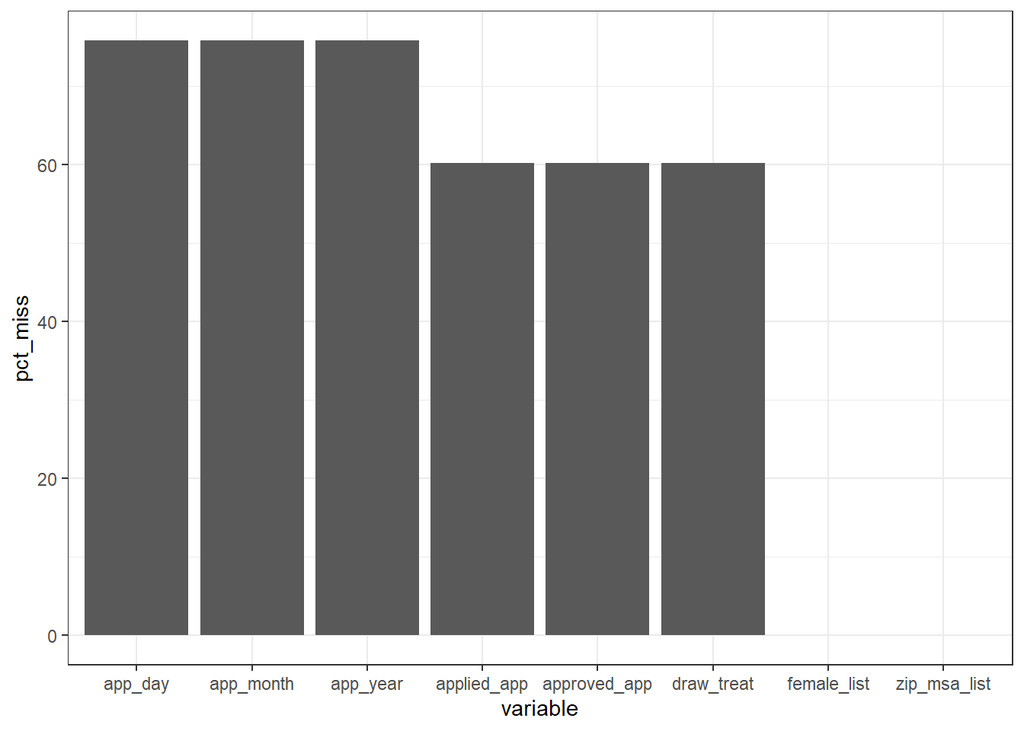

```r
oregon_descriptive |>
  miss_var_summary()|>
  filter(n_miss>0)|>
  ggplot(aes(variable,pct_miss))+
  geom_bar(stat = "identity")
```

```r
#drop columns that have missing values more than 20%
missing_col <- colMeans(is.na(oregon_descriptive))
complete_cols <- missing_col < 0.2
oregon_descriptive_complete <- oregon_descriptive[,complete_cols]

dim(oregon_descriptive_complete)
```

```
[1] 74922    21
```

[figure not shown]

```r
#drop rows if female_list is NA
oregon_descriptive <- oregon_descriptive_complete[complete.cases(oregon_descriptive_complete$female_list, oregon_descriptive_complete$zip_msa_list), ]

oregon_descriptive |>
  miss_var_summary()|>
  filter(n_miss>0)|>
  ggplot(aes(variable,pct_miss))+
  geom_bar(stat = "identity")
```

## 2. oregon_emergency

```r
non_numeric_columns <- names(oregon_emergency)[sapply(oregon_emergency, function(x) !is.numeric(x))]

unique_non_numeric_values <- lapply(oregon_emergency[non_numeric_columns], function(x) unique(x))

for (i in seq_along(non_numeric_columns)) {
  cat("Column:", non_numeric_columns[i], "\n")
  print(unique_non_numeric_values[[i]])
  cat("\n")
}
```

```
Column: any_visit_pre_ed
[1] "No"  "Yes"

Column: any_visit_ed
[1] "No"  "Yes"

Column: any_hosp_pre_ed
[1] "No"  "Yes"

Column: any_hosp_ed
[1] "No"  "Yes"

Column: any_out_pre_ed
[1] "No"  "Yes"

Column: any_out_ed
[1] "No"  "Yes"

Column: any_on_pre_ed
[1] "No"  "Yes"

Column: any_on_ed
[1] "No"  "Yes"

Column: any_off_pre_ed
[1] "No"  "Yes"

Column: any_off_ed
[1] "No"  "Yes"

Column: any_acsc_pre_ed
[1] "No"  "Yes"

Column: any_acsc_ed
[1] "No"  "Yes"

Column: any_chron_pre_ed
[1] "No"  "Yes"

Column: any_chron_ed
```

[output cut: 46 more lines]

```

Column: any_psysub_ed
[1] "No"  "Yes"

Column: any_hiun_pre_ed
[1] "No"  "Yes"

Column: any_hiun_ed
[1] "No"  "Yes"

Column: any_loun_pre_ed
[1] "No"  "Yes"

Column: any_loun_ed
[1] "No"  "Yes"
```

```r
# Replace "Yes" with 1 and "No" with 0
non_numeric_cols <- names(oregon_emergency)[sapply(oregon_emergency, function(x) !is.numeric(x))]

for (col in non_numeric_cols) {
  oregon_emergency[[col]] <- ifelse(oregon_emergency[[col]] == "Yes", 1,
                                    ifelse(oregon_emergency[[col]] == "No", 0, oregon_emergency[[col]]))
}

oregon_emergency <- oregon_emergency |>
  mutate_at(vars(non_numeric_cols), as.numeric)
```

```r
#check

non_numeric_columns <- names(oregon_emergency)[sapply(oregon_emergency, function(x) !is.numeric(x))]

unique_non_numeric_values <- lapply(oregon_emergency[non_numeric_columns], function(x) unique(x))
for (i in seq_along(non_numeric_columns)) {
  cat("Column:", non_numeric_columns[i], "\n")
  print(unique_non_numeric_values[[i]])
  cat("\n")
}
```

#### Missing Values

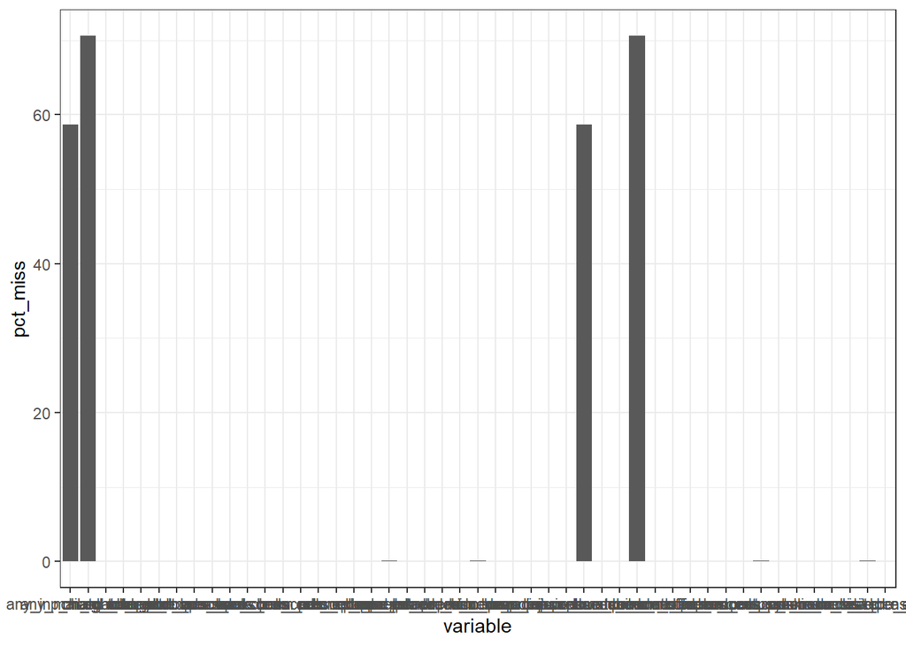

```r
oregon_emergency |>
  miss_var_summary()|>
  filter(n_miss>0)|>
  ggplot(aes(variable,pct_miss))+
  geom_bar(stat = "identity")
```

```r
#drop columns that have more than 40% missing values
missing_col <- colMeans(is.na(oregon_emergency))
complete_cols <- missing_col < 0.4
oregon_emergency <- oregon_emergency[,complete_cols]

dim(oregon_emergency)
```

```
[1] 24646    85
```

```r
#Most of columns are binary and have few missing values - fill with 0
eg_col<- names(oregon_emergency)
oregon_emergency[eg_col][is.na(oregon_emergency[eg_col])] <- 0
```

## 3. oregon_pattern

Setting non-date values to NA

```r
# oregon_patterns <- read.csv("data/oregonhie_patterns_vars.csv")
library(lubridate)
oregon_patterns$dt_notify_treat <- dmy(oregon_patterns$dt_notify_treat)
oregon_patterns$dt_notify_treat[!is.Date(oregon_patterns$dt_notify_treat)] <- NA
```

Converting female list to gender colomn using regex

```r
oregon_patterns$gender <- as.numeric(sub("^(\\d+):.*", "\\1", oregon_patterns$female_list))
oregon_patterns$female_list <- NULL
head(oregon_patterns)
```

```
  X person_id household_id any_visit_180p_180 any_visit_180p_360
1 0      8218       108218                 No                 No
2 1     62755       162755                 No                Yes
3 2     27528       127528                 No                 No
4 3     67031       167031                 No                 No
5 4     45656       145656                 No                Yes
6 5     63182       163182                 No                 No
  any_visit_180p_540 any_visit_180p_720 preperiod_any_visits
1                Yes                 No                   No
2                Yes                 No                  Yes
3                 No                 No                  Yes
4                 No                 No                  Yes
5                 No                 No                  Yes
6                 No                 No                   No
  medicaid_all_180p_period_180 medicaid_all_180p_period_360
```

[output cut: 55 more lines]

Converting texts (have phone list, pobox, ohp_all_ever) to binary

```r
# Custom function: converts to lower, trims whitespace and converts to binary
convert_to_binary <- function(df_column, target_string, true_value = 1, false_value = 0) {
  df_column <- tolower(df_column)
  df_column <- gsub("\\s+|\\$+", "", df_column)
  return(ifelse(df_column == target_string, true_value, false_value))
}

# Applying the function to each column
oregon_patterns$have_phone_list <- convert_to_binary(oregon_patterns$have_phone_list, "gave phone number")
oregon_patterns$pobox_list <- convert_to_binary(oregon_patterns$pobox_list, "not pobox", false_value = 1)
oregon_patterns$ohp_all_ever_inperson <- convert_to_binary(oregon_patterns$ohp_all_ever_inperson, "enrolled")
```

convert all yes/nos into 1,0 with custom function

```r
# Custom function to convert "Yes" to 1 and "No" to 0

convert_yes_no_to_binary <- function(column) {
  ifelse(column == "Yes", 1, 0)
}

# List of column names to convert
columns_to_convert <- c("any_visit_180p_180", "any_visit_180p_360", "any_visit_180p_540",
                        "any_visit_180p_720", "preperiod_any_visits", "medicaid_all_180p_period_180",
                        "medicaid_all_180p_period_360", "medicaid_all_180p_period_540",
                        "medicaid_all_180p_period_720",
                        "doc_any_incl_probe_inp",
                        "any_inp_match_ed",
                        "treatment")

for (column_name in columns_to_convert) {
  oregon_patterns[[column_name]] <- convert_yes_no_to_binary(oregon_patterns[[column_name]])
}


head(oregon_patterns)
```

```
  X person_id household_id any_visit_180p_180 any_visit_180p_360
1 0      8218       108218                  0                  0
2 1     62755       162755                  0                  1
3 2     27528       127528                  0                  0
4 3     67031       167031                  0                  0
5 4     45656       145656                  0                  1
6 5     63182       163182                  0                  0
  any_visit_180p_540 any_visit_180p_720 preperiod_any_visits
1                  1                  0                    0
2                  1                  0                    1
3                  0                  0                    1
4                  0                  0                    1
5                  0                  0                    1
6                  0                  0                    0
  medicaid_all_180p_period_180 medicaid_all_180p_period_360
```

[output cut: 55 more lines]

```r
oregon_patterns$english_list <- ifelse(oregon_patterns$english_list == "Requested materials in language other than english", 1, 0)
oregon_patterns$self_list <- ifelse(oregon_patterns$self_list == "Signed self up", 1, 0)

head(oregon_patterns)
```

```
  X person_id household_id any_visit_180p_180 any_visit_180p_360
1 0      8218       108218                  0                  0
2 1     62755       162755                  0                  1
3 2     27528       127528                  0                  0
4 3     67031       167031                  0                  0
5 4     45656       145656                  0                  1
6 5     63182       163182                  0                  0
  any_visit_180p_540 any_visit_180p_720 preperiod_any_visits
1                  1                  0                    0
2                  1                  0                    1
3                  0                  0                    1
4                  0                  0                    1
5                  0                  0                    1
6                  0                  0                    0
  medicaid_all_180p_period_180 medicaid_all_180p_period_360
```

[output cut: 55 more lines]

Removing Unnecesary Columns

```r
library(dplyr)

# Using dplyr to remove columns
oregon_patterns <- dplyr::select(oregon_patterns, - first_day_list, -dt_completed_inp, -sample_inp_resp, -ed_any_incl_probe_inp, -draw_lottery,-dt_notify_treat)
head(oregon_patterns)
```

```
  X person_id household_id any_visit_180p_180 any_visit_180p_360
1 0      8218       108218                  0                  0
2 1     62755       162755                  0                  1
3 2     27528       127528                  0                  0
4 3     67031       167031                  0                  0
5 4     45656       145656                  0                  1
6 5     63182       163182                  0                  0
  any_visit_180p_540 any_visit_180p_720 preperiod_any_visits
1                  1                  0                    0
2                  1                  0                    1
3                  0                  0                    1
4                  0                  0                    1
5                  0                  0                    1
6                  0                  0                    0
  medicaid_all_180p_period_180 medicaid_all_180p_period_360
```

[output cut: 41 more lines]

Imputation for Missing Values

```r
# Load necessary libraries
library(tidyr)
library(dplyr)

train_data <- oregon_patterns %>% filter(!is.na(weight_total_inp))
prediction_data <- oregon_patterns %>% filter(is.na(weight_total_inp))

# Define the linear regression model using the training data
model <- lm(weight_total_inp ~ weight_720days + weight_540days + weight_360days + weight_180days, data = train_data)

# Predict the missing values using the model
prediction_data$weight_total_inp <- predict(model, newdata = prediction_data)

# Combine the data back together
oregon_patterns <- rbind(train_data, prediction_data)
```

# Exploratory Data Analysis

## Understanding the Responses given by Audience

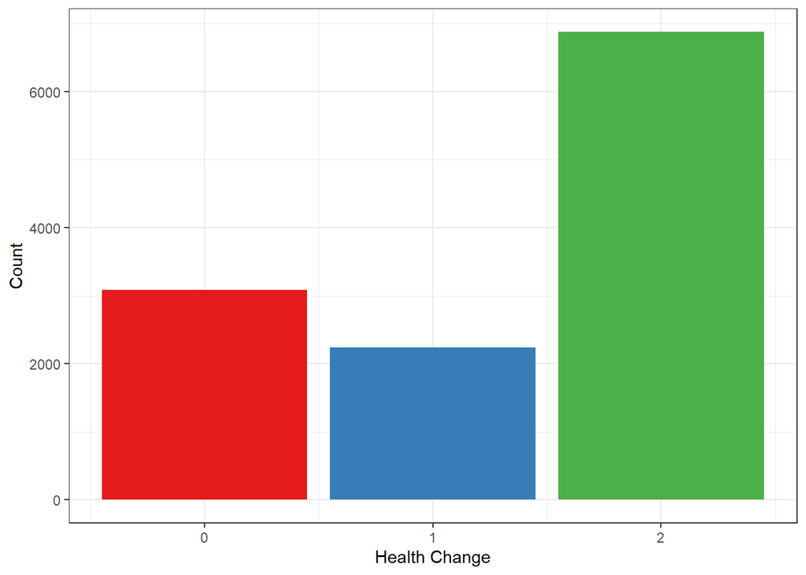

```r
# health_change_inp
#  "1: Worse" "2: About the same" "0: Better"

oregon_in_person_complete |>
  ggplot(aes(x = health_change_inp, fill=as.factor(health_change_inp))) +
  geom_bar()+
  scale_fill_brewer(palette = "Set1") +
  labs(x = "Health Change", y = "Count")+
  theme(legend.position = "none")
```

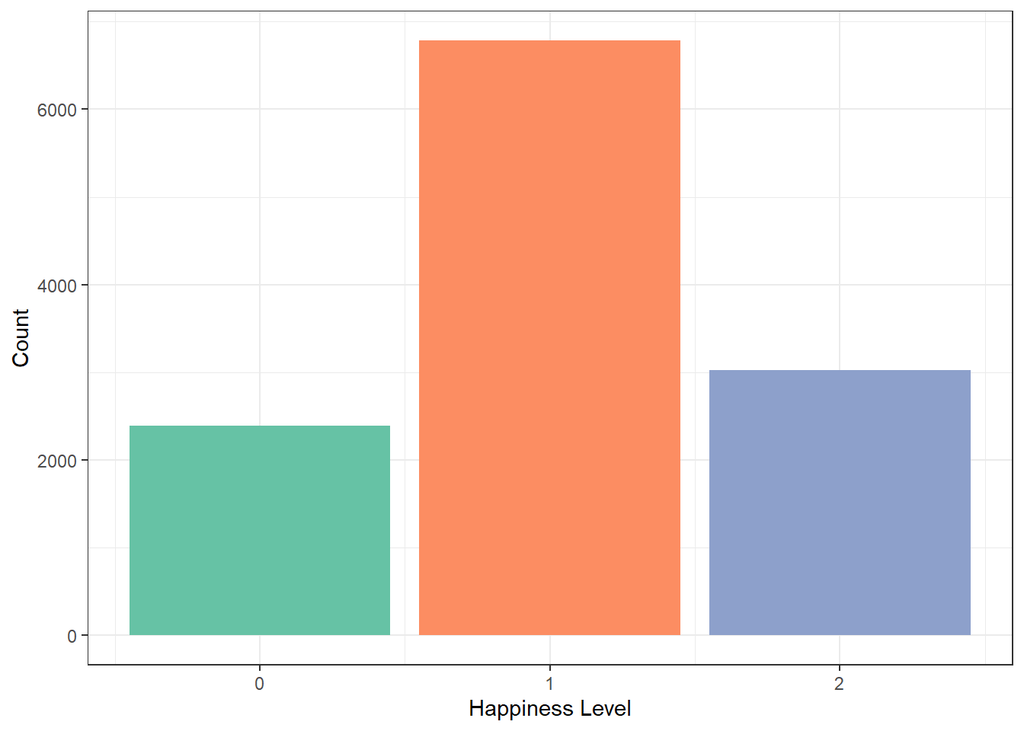

```r
# happiness_inp
# "0: Very happy"    "1: Pretty happy"  "2: Not too happy"
oregon_in_person_complete |>
  ggplot(aes(x = happiness_inp, fill=as.factor(happiness_inp))) +
  geom_bar()+
  scale_fill_brewer(palette = "Set2") +
  labs(x = "Happiness Level", y = "Count")+
  theme(legend.position = "none")
```

We can see that the majority of respondents reported their health as “About the same,” followed by “Better” and “Worse.” This suggests that a significant portion of the audience perceives their health to be relatively stable. An optimistic insight that the lowest response was scored by “worse”.

The second visualization displays the distribution of happiness levels among the respondents. We observe that most respondents reported being “Pretty happy,” with fewer respondents indicating being “Very happy” or “Not too happy.” This indicates that the audience generally perceives themselves to be moderately happy.

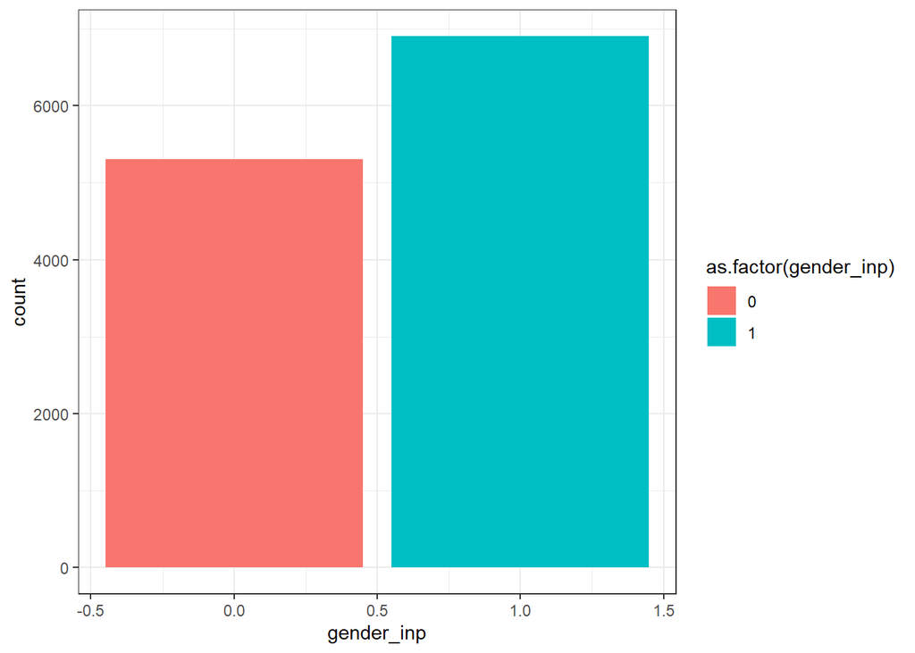

```r
oregon_in_person_complete |>
  ggplot(aes(x=gender_inp,fill=as.factor(gender_inp))) +
  geom_bar()
```

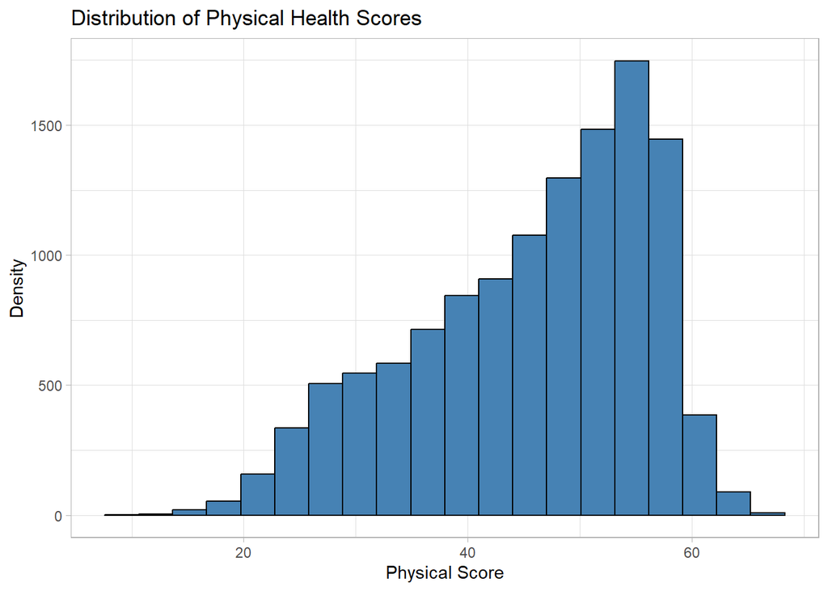

```r
oregon_in_person_complete |>
ggplot(aes(x = pcs8_score_inp)) +
  geom_histogram(bins = 20, color = "black", fill = "steelblue") +
  labs(title = "Distribution of Physical Health Scores", x = "Physical Score", y = "Density") +
  theme_light()
```

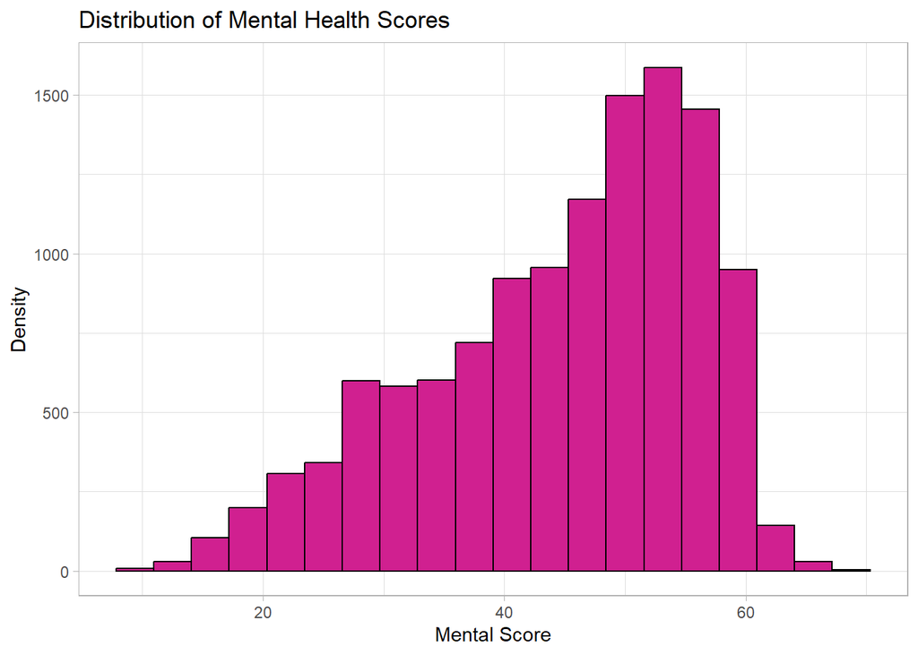

```r
oregon_in_person_complete |>
ggplot(aes(x = mcs8_score_inp)) +
  geom_histogram(bins = 20, color = "black", fill = "violetred") +
  labs(title = "Distribution of Mental Health Scores", x = "Mental Score", y = "Density") +
  theme_light()
```

More people tend to have higher mental and physical health scores in the range of 40 - 60.

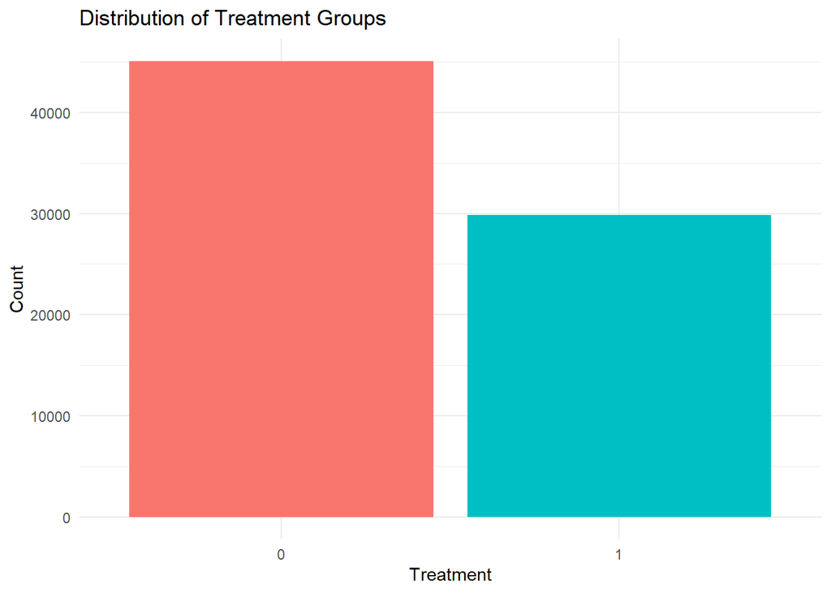

```r
oregon_descriptive |>
  mutate(
    treatment = as.factor(treatment),
    draw_lottery = as.factor(draw_lottery)
  ) |>
  ggplot(aes(x = treatment, fill = treatment)) +
  geom_bar() +
  labs(title = "Distribution of Treatment Groups", x = "Treatment", y = "Count") +
  theme_minimal() +
  theme(legend.position = "none")
```

# Data Preprocessing

### Create Dataset for modeling

```r
#Based on the columns description and relativess, we filtered out some columns like zipcode, id columns etc.
oregon_in_person_filtered <- oregon_in_person_complete |>
  dplyr::select(
    person_id,
    weight_total_inp,
    age_inp,
    race_white_inp,
    ins_any_inp,
    health_last12_inp,
    chl_inp,
    bmi_inp,
    bp_dar_inp,
    bp_sar_inp,
    health_change_inp,
    sf4_inp,
    ast_dx_pre_lottery_inp,
    dia_dx_pre_lottery_inp,
    hbp_dx_pre_lottery_inp,
    chl_dx_pre_lottery_inp,
    ami_dx_pre_lottery_inp,
    chf_dx_pre_lottery_inp,
    emp_dx_pre_lottery_inp,
    kid_dx_pre_lottery_inp,
    cancer_dx_pre_lottery_inp,
    dep_dx_pre_lottery_inp,
    dia_dx_post_lottery_inp,
    hbp_dx_post_lottery_inp,
    chl_dx_post_lottery_inp,
    dep_dx_post_lottery_inp,
    happiness_inp,
    phqtot_inp,
    doc_num_incl_probe_inp,
    hosp_num_incl_probe_inp,
    pcs8_score_inp,
    mcs8_score_inp
  )
```

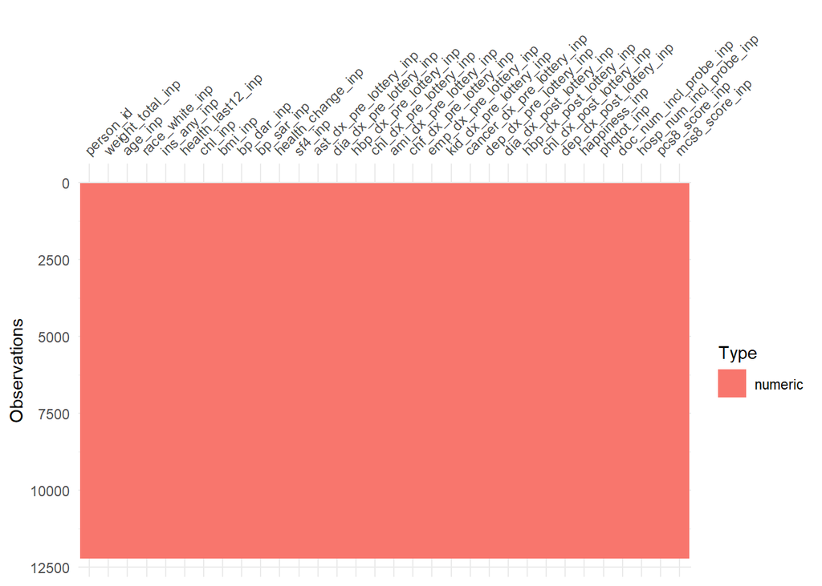

```r
oregon_in_person_filtered|>
  vis_dat()
```

### Merged data

```r
#mearge oregon_in_person with oregon_descriptive
merged_data <- oregon_in_person_filtered |>
  left_join(oregon_descriptive|>
              dplyr::select(person_id, female_list, treatment), by = "person_id")
dim(merged_data)
```

```
[1] 12204    34
```

```r
#merge with oregon_emergency
merged_data <- merged_data |>
  inner_join(oregon_emergency|>
              dplyr::select(
                person_id,
                num_visit_cens_ed, # Number of ED visits in the study period (Censored)
                num_hosp_cens_ed, #Number ED visit resulting in a hospitalization in the study period
                charg_tot_ed #Sum of total charges in the study period
                ), by = "person_id")
dim(merged_data)
```

```
[1] 10157    37
```

```r
#merge with oregon_patterns
merged_data <- merged_data |>
  inner_join(oregon_patterns|>
              dplyr::select(
                person_id,
                weight_720days, #Weight at 720 days after lottery notification
                weight_total_inp,
                ohp_all_ever_inperson #Ever enrolled in Medicaid from 10mar2008 until in-person interview date
                ), by = "person_id")
dim(merged_data)
```

```
[1] 10157    40
```

### Converting Target Variables for Mental and Physical Health

- First target variable: **`health_chage_inp`**

Change the value “2” to “0” since it represents “About the same”. Converting the variable to a binary format with “0” representing “Better(Not bad)” and “1” representing “Worse” will make it suitable as a target variable for binary classification tasks.

- Second target variable: **`happiness_inp`**

Convert to a binary variable where “0” represents “Happy” (values 0 and 1) and “1” represents “Not happy” (value 2).

```r
# health_change_inp
#  "1: Worse" "2: About the same" "0: Better"
# 0 + 2 -> 0, 1 -> 1
table(merged_data$health_change_inp)
```

```
   0    1    2
2567 1882 5708
```

```r
merged_data$health_change_inp <- ifelse(merged_data$health_change_inp == 2, 0, merged_data$health_change_inp)

table(merged_data$health_change_inp)
```

```
   0    1
8275 1882
```

```r
# happiness_inp
# "0: Very happy"    "1: Pretty happy"  "2: Not too happy"
# 0 + 1 -> 0, 2 -> 1

table(merged_data$happiness_inp)
```

```
   0    1    2
1983 5645 2529
```

```r
merged_data$happiness_inp <- ifelse(merged_data$happiness_inp %in% c(0, 1), 0, 1)

table(merged_data$happiness_inp)
```

```
   0    1
7628 2529
```

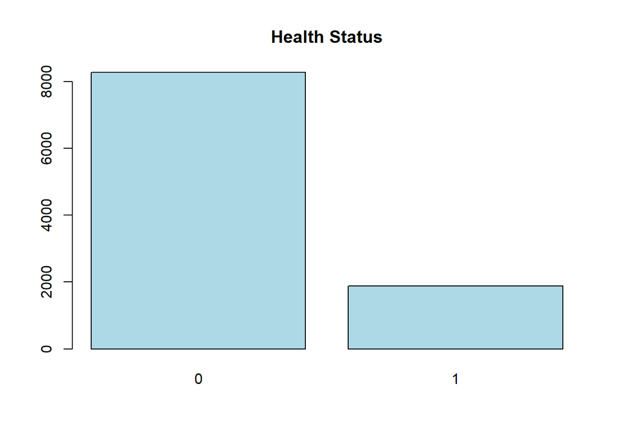

```r
health_counts <- table(merged_data$health_change_inp)
happy_counts <- table(merged_data$happiness_inp)

barplot(health_counts, col = "lightblue", main = "Health Status")
```

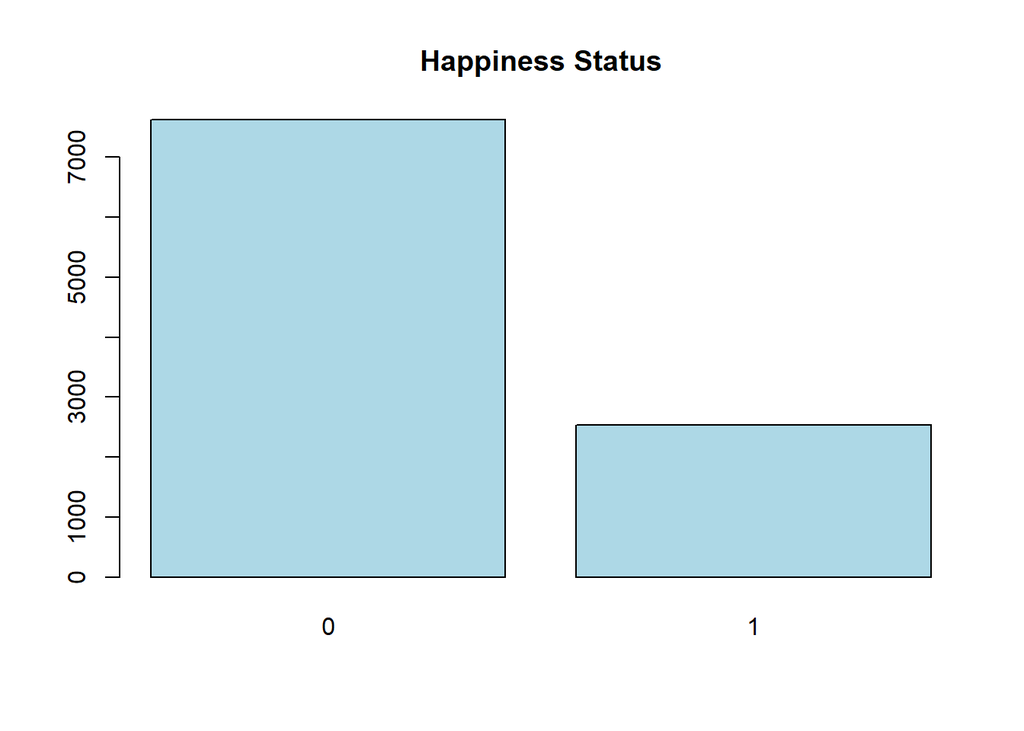

```r
barplot(happy_counts, col = "lightblue", main = "Happiness Status")
```

### covert to factor variables

```r
convert_to_factor <- function(df) {
  for (col_name in names(df)) {
    unique_values <- unique(na.omit(df[[col_name]]))
    if (length(unique_values) <= 10) {
      df[[col_name]] <- factor(df[[col_name]])
    }
  }
  return(df)
}

modelling_data<-merged_data|>
  dplyr::select(-c(person_id))

modelling_data_final <- convert_to_factor(modelling_data)

str(modelling_data_final)
```

```
'data.frame':   10157 obs. of  39 variables:
 $ weight_total_inp.x       : num  1 1.16 1 1 1 ...
 $ age_inp                  : num  57 22 45 54 27 39 22 46 27 28 ...
 $ race_white_inp           : Factor w/ 2 levels "0","1": 2 2 2 2 2 2 2 2 2 2 ...
 $ ins_any_inp              : Factor w/ 2 levels "0","1": 2 1 1 1 1 2 2 2 2 1 ...
 $ health_last12_inp        : Factor w/ 6 levels "1","2","3","4",..: 5 5 4 3 4 2 4 5 4 4 ...
 $ chl_inp                  : num  222 195 221 222 208 ...
 $ bmi_inp                  : num  28.7 18 20.4 23.9 39.2 ...
 $ bp_dar_inp               : num  69 79 54 63 70 81 86 82 66 71 ...
 $ bp_sar_inp               : num  101 127 101 104 121 108 123 117 97 127 ...
 $ health_change_inp        : Factor w/ 2 levels "0","1": 1 1 2 1 1 1 1 1 1 1 ...
 $ sf4_inp                  : Factor w/ 6 levels "0","1","2","3",..: 1 2 4 3 2 5 2 1 2 1 ...
 $ ast_dx_pre_lottery_inp   : Factor w/ 2 levels "0","1": 2 1 2 1 1 1 1 1 1 1 ...
 $ dia_dx_pre_lottery_inp   : Factor w/ 2 levels "0","1": 1 1 1 1 1 1 1 1 1 1 ...
 $ hbp_dx_pre_lottery_inp   : Factor w/ 2 levels "0","1": 1 1 1 2 1 1 1 1 1 1 ...
```

[output cut: 25 more lines]

# Modeling

We performed **Principal Component Analysis (PCA)** to reduce the dimensionality of the dataset while preserving its essential information, aiding in better understanding the underlying patterns and relationships within the data.

```r
write.csv(modelling_data_final, "cleaned_combined_modelling_data/classification_modelling_data.csv", row.names = FALSE)
```

## Classification for Mental Health - Predicting Happiness Response

### Define the Recipe

```r
happy_rcp <- recipe(happiness_inp ~ .
                     ,data = modelling_data_final)|>
  step_normalize(all_numeric_predictors()) |>
  step_pca(all_numeric_predictors(),
           num_comp = 10) |>
  step_dummy(all_nominal_predictors())
```

### Model1: Logistic Regression

```r
parsnip_1 <- logistic_reg() |>
  set_mode("classification") |>
  set_engine("glm")

workflow_1 <- workflow() |>
  add_model(parsnip_1) |>
  add_recipe(happy_rcp)
```

### Model2: Logistic regression using the lasso

```r
parsnip_2 <- logistic_reg(penalty = 0.01) |>
  set_mode("classification") |>
  set_engine("glmnet")

workflow_2 <- workflow() |>
  add_model(parsnip_2) |>
  add_recipe(happy_rcp)
```

### Model3 : K-nearest neighbors model (K = 5)

```r
parsnip_3 <- nearest_neighbor() |>
  set_mode("classification") |>
  set_engine("kknn",
             neighbors = 5)

workflow_3 <- workflow() |>
  add_model(parsnip_3) |>
  add_recipe(happy_rcp)
```

### Model4 : K-nearest neighbors model (K = 1)

```r
parsnip_4 <- nearest_neighbor() |>
  set_mode("classification") |>
  set_engine("kknn",
             neighbors = 1)

workflow_4 <- workflow() |>
  add_model(parsnip_4) |>
  add_recipe(happy_rcp)
```

### Model5 : Random Forest model

```r
parsnip_5 <- rand_forest() |>
  set_mode("classification") |>
  set_engine("ranger")

workflow_5 <- workflow() |>
  add_model(parsnip_5) |>
  add_recipe(happy_rcp)
```

### Split the data

```r
set.seed(11)
happy_split <- initial_split(modelling_data_final,
                              prop = 0.7,
                              strata = happiness_inp)

happy_train <- happy_split |>
  training()

happy_test <- happy_split |>
  testing()
```

### Assembling

```r
workflow_names <- c("glm",
                    "glm_lasso",
                    "knn_5",
                    "knn_1",
                    "rf")

workflow_objects <- list(workflow_1,
                         workflow_2,
                         workflow_3,
                         workflow_4,
                         workflow_5)

workflows_tbl <- tibble(work_names = workflow_names,
                        work_objects = workflow_objects)
```

fitting the model

```r
set.seed(1)
workflows_tbl <-  workflows_tbl |>
  rowwise() |>
  mutate(fits = list(fit(work_objects,
                         happy_train)))
```

## Model Evaluatation

```r
workflows_tbl_predictions <- workflows_tbl |>
  mutate(pred_class = list(predict(fits,
                                   happy_test,
                                   type = "class"))) |>
  mutate(pred_prob = list(predict(fits,
                                  happy_test,
                                  type = "prob")))

workflows_tbl_predictions <- workflows_tbl_predictions |>
  mutate(predictions = list(bind_cols(pred_class, pred_prob))) |>
  dplyr::select(-c(pred_class, pred_prob))
```

```r
predictions_tbl  <- workflows_tbl_predictions |>
  dplyr::select(work_names,
         predictions) |>
  unnest(cols = c(predictions)) |>
  cbind(happiness_inp = happy_test |>
          pull(happiness_inp))

glimpse(predictions_tbl)
```

```
Rows: 15,240
Columns: 5
$ work_names    <chr> "glm", "glm", "glm", "glm", "glm", "glm", "glm", "glm", …
$ .pred_class   <fct> 0, 0, 0, 0, 1, 0, 0, 1, 0, 0, 0, 1, 0, 0, 0, 0, 0, 0, 1,…
$ .pred_0       <dbl> 0.94229460, 0.85844364, 0.93473249, 0.92852144, 0.302509…
$ .pred_1       <dbl> 0.05770540, 0.14155636, 0.06526751, 0.07147856, 0.697490…
$ happiness_inp <fct> 0, 0, 0, 0, 1, 0, 0, 1, 0, 0, 0, 1, 0, 0, 0, 0, 0, 0, 0,…
```

### Assessing estimated **probabilities**

ROC Curve

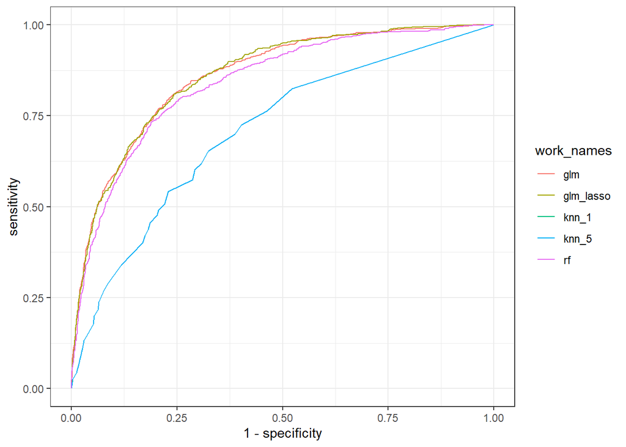

```r
roc_all <- predictions_tbl |>
  group_by(work_names) |>
  roc_curve(truth = happiness_inp,
            .pred_1,
            event_level = "second")

roc_all |>
  ggplot(aes(x = 1- specificity,
             y = sensitivity,
             color = work_names)) +
  geom_path()
```

```r
roc_auc_all <- predictions_tbl |>
  group_by(work_names) |>
  roc_auc(truth = happiness_inp,
          .pred_1,
          event_level = "second")

roc_auc_all
```

```
# A tibble: 5 × 4
  work_names .metric .estimator .estimate
  <chr>      <chr>   <chr>          <dbl>
1 glm        roc_auc binary         0.859
2 glm_lasso  roc_auc binary         0.860
3 knn_1      roc_auc binary         0.708
4 knn_5      roc_auc binary         0.708
5 rf         roc_auc binary         0.841
```

### Re-substituting the data

```r
workflows_resub <- workflows_tbl |>
  mutate(predictions = list(predict(fits,
                                    happy_train,
                                    type = "class")))


predictions_resub  <- workflows_resub |>
  dplyr::select(work_names,
         predictions) |>
  unnest(cols = c(predictions)) |>
  cbind(happiness_inp = happy_train |>
          pull(happiness_inp))
```

```r
predictions_resub |>
  group_by(work_names) |>
  accuracy(truth = happiness_inp,
           estimate = .pred_class)
```

```
# A tibble: 5 × 4
  work_names .metric  .estimator .estimate
  <chr>      <chr>    <chr>          <dbl>
1 glm        accuracy binary         0.831
2 glm_lasso  accuracy binary         0.822
3 knn_1      accuracy binary         1
4 knn_5      accuracy binary         1
5 rf         accuracy binary         0.969
```

### Validation Set

```r
set.seed(1)
val_set <- validation_split(happy_train,
                            prop = 0.75,
                            strata = happiness_inp)
```

```r
val_set |>
  class()
```

```
[1] "validation_split" "rset"             "tbl_df"           "tbl"
[5] "data.frame"
```

```r
set.seed(1)
happy_metric_set <- metric_set(accuracy,
                                roc_auc)

workflows_val <- workflows_tbl |>
  mutate(fits = list(fit_resamples(work_objects,
                                   val_set,
                                   metrics = happy_metric_set))) |>
  mutate(metrics = list(collect_metrics(fits)))

workflows_val |>
  dplyr::select(c(work_names,
           metrics)) |>
  unnest(metrics) |>
  arrange(.metric)
```

```
# A tibble: 10 × 7
   work_names .metric  .estimator  mean     n std_err .config
   <chr>      <chr>    <chr>      <dbl> <int>   <dbl> <chr>
 1 glm        accuracy binary     0.831     1      NA Preprocessor1_Model1
 2 glm_lasso  accuracy binary     0.825     1      NA Preprocessor1_Model1
 3 knn_5      accuracy binary     0.728     1      NA Preprocessor1_Model1
 4 knn_1      accuracy binary     0.728     1      NA Preprocessor1_Model1
 5 rf         accuracy binary     0.810     1      NA Preprocessor1_Model1
 6 glm        roc_auc  binary     0.861     1      NA Preprocessor1_Model1
 7 glm_lasso  roc_auc  binary     0.859     1      NA Preprocessor1_Model1
 8 knn_5      roc_auc  binary     0.727     1      NA Preprocessor1_Model1
 9 knn_1      roc_auc  binary     0.727     1      NA Preprocessor1_Model1
10 rf         roc_auc  binary     0.847     1      NA Preprocessor1_Model1
```

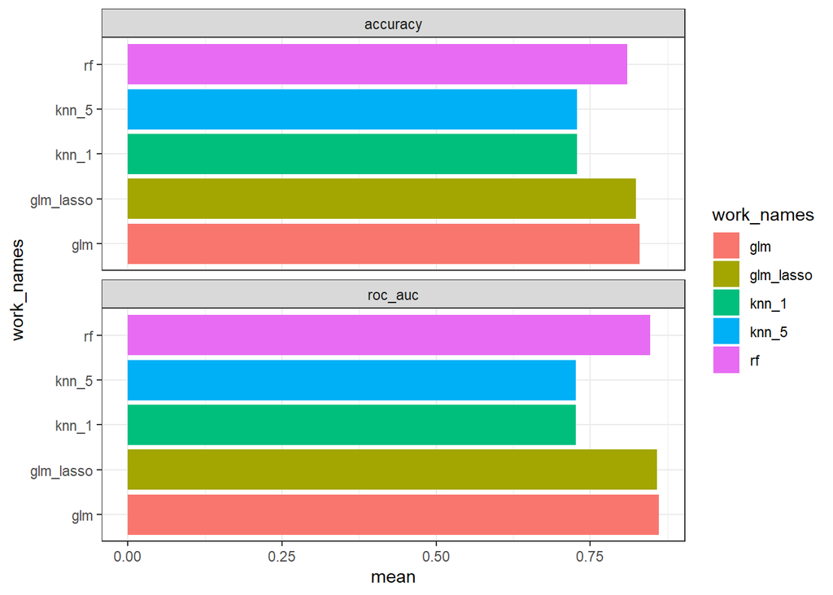

```r
workflows_val |>
  dplyr::select(c(work_names,
           metrics)) |>
  unnest(metrics) |>
  ggplot(aes(y = work_names,
             fill = work_names,
             x = mean)) +
  geom_col() +
  facet_wrap(~.metric,
             nrow = 2)
```

```r
validation_performance <- workflows_val |>
  dplyr::select(c(work_names,
           metrics)) |>
  unnest(metrics) |>
  filter(.metric == "accuracy") |>
  arrange(work_names)

resub_performance <- predictions_resub |>
  group_by(work_names) |>
  accuracy(truth = happiness_inp,
           estimate = .pred_class) |>
  arrange(work_names)

test_performance <- predictions_tbl |>
  group_by(work_names) |>
  accuracy(truth = happiness_inp,
           estimate = .pred_class) |>
  arrange(work_names)

comparison <- test_performance |>
  dplyr::select(work_names) |>
  mutate(estimate_test = test_performance |> pull(.estimate),
         estimate_val = validation_performance |> pull(mean),
         estimate_resub = resub_performance |> pull(.estimate))

comparison
```

```
# A tibble: 5 × 4
  work_names estimate_test estimate_val estimate_resub
  <chr>              <dbl>        <dbl>          <dbl>
1 glm                0.828        0.831          0.831
2 glm_lasso          0.827        0.825          0.822
3 knn_1              0.724        0.728          1
4 knn_5              0.724        0.728          1
5 rf                 0.813        0.810          0.969
```

## Classification for Physical Health - Predicting Health Change Response

### Defining the Recipe

```r
healthchange_rcp <- recipe(health_change_inp ~ .
                     ,data = modelling_data_final)|>
  step_normalize(all_numeric_predictors()) |>
  step_pca(all_numeric_predictors(),
           num_comp = 10) |>
  step_dummy(all_nominal_predictors())
```

### Model 6: Logistic Regression

```r
parsnip_6 <- logistic_reg() |>
  set_mode("classification") |>
  set_engine("glm")

workflow_6 <- workflow() |>
  add_model(parsnip_1) |>
  add_recipe(healthchange_rcp)
```

### Model 7: Logistic regression using lasso

```r
parsnip_7 <- logistic_reg(penalty = 0.01) |>
  set_mode("classification") |>
  set_engine("glmnet")

workflow_7 <- workflow() |>
  add_model(parsnip_2) |>
  add_recipe(healthchange_rcp)
```

### Model 8 : K-nearest neighbors model (K = 5)

```r
parsnip_8 <- nearest_neighbor() |>
  set_mode("classification") |>
  set_engine("kknn",
             neighbors = 5)

workflow_8 <- workflow() |>
  add_model(parsnip_3) |>
  add_recipe(healthchange_rcp)
```

### Model 9 : K-nearest neighbors model (K = 1)

```r
parsnip_9 <- nearest_neighbor() |>
  set_mode("classification") |>
  set_engine("kknn",
             neighbors = 1)

workflow_9 <- workflow() |>
  add_model(parsnip_4) |>
  add_recipe(healthchange_rcp)
```

### Model 10 : Random Forest model

```r
parsnip_10 <- rand_forest() |>
  set_mode("classification") |>
  set_engine("ranger")

workflow_10 <- workflow() |>
  add_model(parsnip_5) |>
  add_recipe(healthchange_rcp)
```

### Split the Data

```r
set.seed(11)
healthchange_split <- initial_split(modelling_data_final,
                              prop = 0.7,
                              strata = health_change_inp)

healthchange_train<- healthchange_split |>
  training()

healthchange_test <- healthchange_split |>
  testing()
```

### Assembling Models

```r
workflow_names1 <- c("glm",
                    "glm_lasso",
                    "knn_5",
                    "knn_1",
                    "rf")

workflow_objects1 <- list(workflow_6,
                         workflow_7,
                         workflow_8,
                         workflow_9,
                         workflow_10)

workflows_tbl1 <- tibble(work_names = workflow_names,
                        work_objects = workflow_objects)
```

## Model Evaluation

### Assessing estimated **probabilities**

```r
set.seed(1)
workflows_tbl1 <-  workflows_tbl1 |>
  rowwise() |>
  mutate(fits = list(fit(work_objects,
                         healthchange_train)))

workflows_tbl_predictions1 <- workflows_tbl1 |>
  mutate(pred_class = list(predict(fits,
                                   healthchange_test,
                                   type = "class"))) |>
  mutate(pred_prob = list(predict(fits,
                                  healthchange_test,
                                  type = "prob")))

workflows_tbl_predictions1 <- workflows_tbl_predictions1 |>
  mutate(predictions = list(bind_cols(pred_class, pred_prob))) |>
  dplyr::select(-c(pred_class, pred_prob))
```

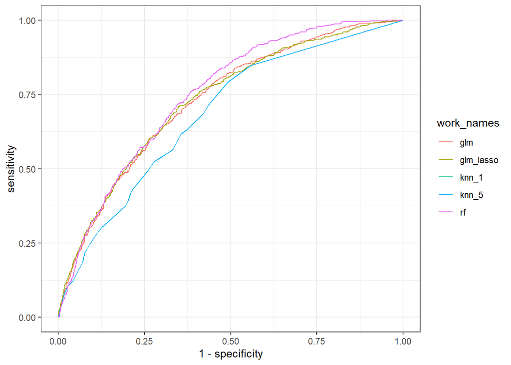

```r
predictions_tbl1  <- workflows_tbl_predictions1 |>
  dplyr::select(work_names,
         predictions) |>
  unnest(cols = c(predictions)) |>
  cbind(health_change_inp = healthchange_test |>
          pull(health_change_inp))


roc_all <- predictions_tbl1 |>
  group_by(work_names) |>
  roc_curve(truth = health_change_inp,
            .pred_1,
            event_level = "second")


roc_all |>
  ggplot(aes(x = 1- specificity,
             y = sensitivity,
             color = work_names)) +
  geom_path()
```

```r
roc_auc_all1 <- predictions_tbl1 |>
  group_by(work_names) |>
  roc_auc(truth = health_change_inp,
          .pred_1,
          event_level = "second")

roc_auc_all1
```

```
# A tibble: 5 × 4
  work_names .metric .estimator .estimate
  <chr>      <chr>   <chr>          <dbl>
1 glm        roc_auc binary         0.730
2 glm_lasso  roc_auc binary         0.730
3 knn_1      roc_auc binary         0.684
4 knn_5      roc_auc binary         0.684
5 rf         roc_auc binary         0.749
```

## Regression for Predicting Overall Physical and Mental Health

Creating the continuous response variable

```r
merged_data <- merged_data |>
  mutate(health_score = (pcs8_score_inp + mcs8_score_inp) / 2) |>
  dplyr::select(-c(pcs8_score_inp, mcs8_score_inp))
```

Converting to factor Variables.

```r
modelling_data<-merged_data|>
  dplyr::select(-c(person_id))

modelling_data_final <- convert_to_factor(modelling_data)

str(modelling_data_final)
```

```
'data.frame':   10157 obs. of  38 variables:
 $ weight_total_inp.x       : num  1 1.16 1 1 1 ...
 $ age_inp                  : num  57 22 45 54 27 39 22 46 27 28 ...
 $ race_white_inp           : Factor w/ 2 levels "0","1": 2 2 2 2 2 2 2 2 2 2 ...
 $ ins_any_inp              : Factor w/ 2 levels "0","1": 2 1 1 1 1 2 2 2 2 1 ...
 $ health_last12_inp        : Factor w/ 6 levels "1","2","3","4",..: 5 5 4 3 4 2 4 5 4 4 ...
 $ chl_inp                  : num  222 195 221 222 208 ...
 $ bmi_inp                  : num  28.7 18 20.4 23.9 39.2 ...
 $ bp_dar_inp               : num  69 79 54 63 70 81 86 82 66 71 ...
 $ bp_sar_inp               : num  101 127 101 104 121 108 123 117 97 127 ...
 $ health_change_inp        : Factor w/ 2 levels "0","1": 1 1 2 1 1 1 1 1 1 1 ...
 $ sf4_inp                  : Factor w/ 6 levels "0","1","2","3",..: 1 2 4 3 2 5 2 1 2 1 ...
 $ ast_dx_pre_lottery_inp   : Factor w/ 2 levels "0","1": 2 1 2 1 1 1 1 1 1 1 ...
 $ dia_dx_pre_lottery_inp   : Factor w/ 2 levels "0","1": 1 1 1 1 1 1 1 1 1 1 ...
 $ hbp_dx_pre_lottery_inp   : Factor w/ 2 levels "0","1": 1 1 1 2 1 1 1 1 1 1 ...
```

[output cut: 24 more lines]

```r
write.csv(modelling_data_final, "cleaned_combined_modelling_data/regression_modelling_data.csv", row.names = FALSE)
```

### Defining the Recipe

```r
health_recipe <- recipe(health_score ~ .,data = modelling_data_final)|>
  step_normalize(all_numeric_predictors()) |>
  step_pca(all_numeric_predictors(),
           num_comp = 5) |>
  step_dummy(all_nominal_predictors())
```

### Model 1: Linear Regression

```r
linear_reg_spec <- linear_reg() |>
  set_mode("regression") |>
  set_engine("lm")

workflow_lm <- workflow() |>
  add_recipe(health_recipe) |>
  add_model(linear_reg_spec)
```

### Model 2: KNN using k = 10

```r
knn_spec <- nearest_neighbor(neighbors = 10) |>
  set_engine("kknn") |>
  set_mode("regression")

workflow_knn <- workflow() |>
  add_recipe(health_recipe) |>
  add_model(knn_spec)
```

### Model 3: Decision tree

```r
dtree_spec <- decision_tree() |>
  set_engine("rpart") |>
  set_mode("regression")

workflow_dt <- workflow() |>
  add_recipe(health_recipe) |>
  add_model(dtree_spec)
```

### Model 4: Random Forest with 50 Trees

```r
rf_spec <- rand_forest(trees = 50) |>
  set_mode("regression") |>
  set_engine("ranger")

workflow_rf <- workflow() |>
  add_recipe(health_recipe) |>
  add_model(rf_spec)
```

### Model 5: XGBoost

```r
xgb_spec <- boost_tree(trees = 50) |>
  set_engine("xgboost") |>
  set_mode("regression")

workflow_xgb <- workflow() |>
  add_recipe(health_recipe) |>
  add_model(xgb_spec)
```

### Splitting Data into Train And Test:

Splitting the data into a testing and training set with 80 percent of the data being used for training, 20 percent being used for test.

```r
set.seed(1)
data_split <- initial_split(modelling_data_final, prop = 0.80)
train_data <- training(data_split)
test_data <- testing(data_split)
```

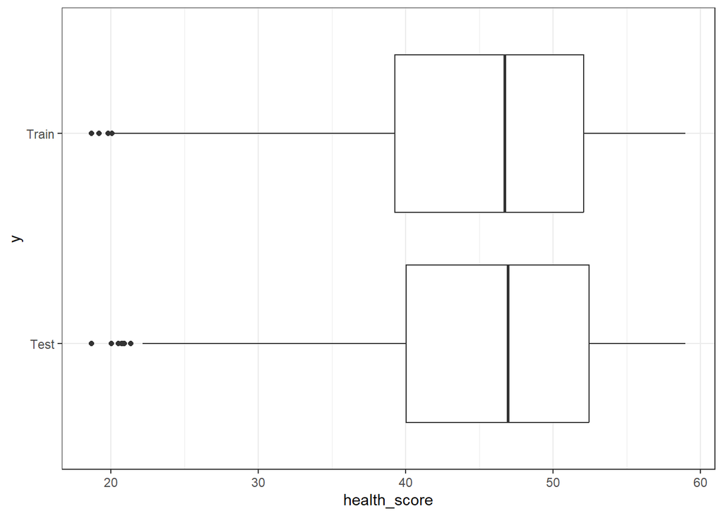

```r
ggplot(data = train_data, aes(x = health_score)) +
  geom_boxplot(aes(y = "Train")) +
  geom_boxplot(data = test_data, aes(y = "Test")) +
  scale_x_continuous(labels = label_number(scale_cut = cut_short_scale()))
```

Because they are randomly split, chances are that the split will be balanced. This balance looks pretty good.

```r
workflow_names <-
  c(
    "Linear Regression",
    "K-Nearest Neighbors",
    "Decision Tree",
    "Random Forest",
    "XGBoost"
  )

workflow_objects <-
  list(workflow_lm,
       workflow_knn,
       workflow_dt,
       workflow_rf,
       workflow_xgb)

workflows_tbl <- tibble(workflow_names = workflow_names,
                        workflow_objects = workflow_objects)

workflows_tbl <-  workflows_tbl |>
  rowwise() |>
  mutate(fits = list(fit(workflow_objects,
                         train_data)))
```

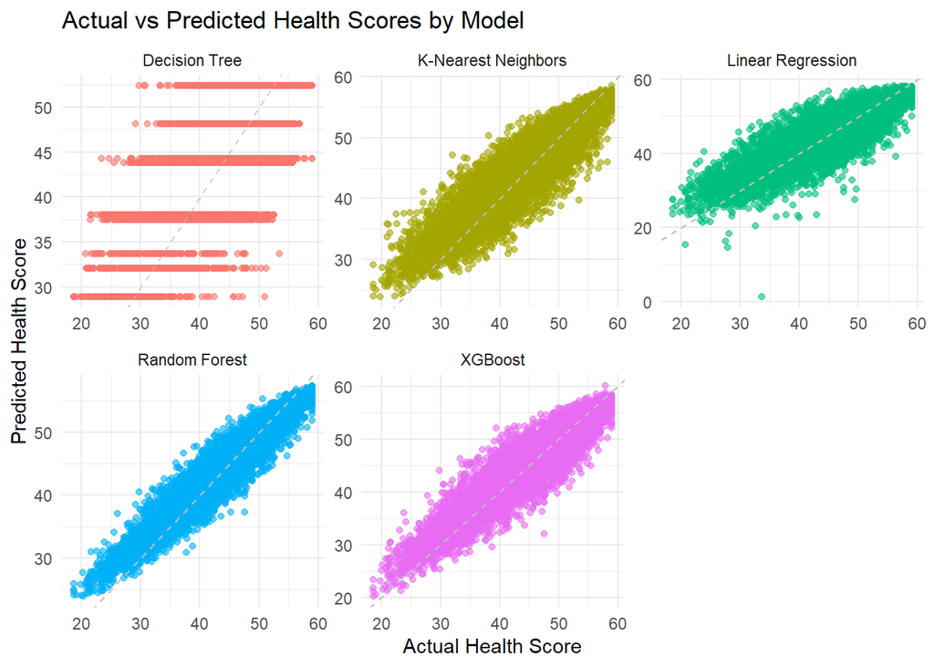

```r
workflows_resub <- workflows_tbl |>
  mutate(predictions = list(predict(fits,
                                    train_data)))



predictions_resub  <- workflows_resub |>
  dplyr::select(workflow_names,
         predictions) |>
  unnest(cols = c(predictions)) |>
  cbind(health_score = train_data |>
          pull(health_score))

ggplot(predictions_resub, aes(x = health_score, y = .pred)) +
  geom_point(aes(color = workflow_names), alpha = 0.6) +
  geom_abline(intercept = 0, slope = 1, linetype = "dashed", color = "gray") +  # Add a 45-degree line
  facet_wrap(~workflow_names, scales = "free") +
  labs(title = "Actual vs Predicted Health Scores by Model",
       x = "Actual Health Score",
       y = "Predicted Health Score") +
  theme_minimal() +
  theme(legend.position = "none")
```

Defining Metric set for regression problem:

```r
regression_metric_set <- metric_set(rmse, rsq, mae)
```

Lets use bootstrap resampling method

```r
bootstrap_resamples <- bootstraps(train_data, times = 10)
```

Creating a function to evaluate bootstrap resmaples

```r
bootstrap_evaluate <- function(workflow, resamples) {
  fit_resamples(
    workflow,
    resamples = resamples,
    metrics = metric_set(rmse, rsq)
  )
}
```

```r
set.seed(1)
workflows_bootstrap <- workflows_tbl |>
  mutate(fits = list(fit_resamples(workflow_objects,
                                         bootstrap_resamples,
                                         metrics = regression_metric_set))) |>
  mutate(metrics = list(collect_metrics(fits)))
```

```
→ A | warning: prediction from rank-deficient fit; consider predict(., rankdeficient="NA")
```

```
There were issues with some computations   A: x1
```

```
There were issues with some computations   A: x2
There were issues with some computations   A: x2
```

```r
bootstrap_results <- workflows_bootstrap |>
  dplyr::select(c(workflow_names,
           metrics)) |>
  unnest(metrics) |>
  arrange(.metric)

bootstrap_results
```

```
# A tibble: 15 × 7
   workflow_names      .metric .estimator  mean     n std_err .config
   <chr>               <chr>   <chr>      <dbl> <int>   <dbl> <chr>
 1 Linear Regression   mae     standard   3.39     10 0.0178  Preprocessor1_Mod…
 2 K-Nearest Neighbors mae     standard   4.22     10 0.0236  Preprocessor1_Mod…
 3 Decision Tree       mae     standard   4.22     10 0.0247  Preprocessor1_Mod…
 4 Random Forest       mae     standard   3.57     10 0.0178  Preprocessor1_Mod…
 5 XGBoost             mae     standard   3.47     10 0.0140  Preprocessor1_Mod…
 6 Linear Regression   rmse    standard   4.34     10 0.0215  Preprocessor1_Mod…
 7 K-Nearest Neighbors rmse    standard   5.46     10 0.0324  Preprocessor1_Mod…
 8 Decision Tree       rmse    standard   5.31     10 0.0265  Preprocessor1_Mod…
 9 Random Forest       rmse    standard   4.50     10 0.0182  Preprocessor1_Mod…
10 XGBoost             rmse    standard   4.44     10 0.0155  Preprocessor1_Mod…
11 Linear Regression   rsq     standard   0.744    10 0.00213 Preprocessor1_Mod…
12 K-Nearest Neighbors rsq     standard   0.604    10 0.00442 Preprocessor1_Mod…
13 Decision Tree       rsq     standard   0.617    10 0.00453 Preprocessor1_Mod…
14 Random Forest       rsq     standard   0.733    10 0.00165 Preprocessor1_Mod…
15 XGBoost             rsq     standard   0.732    10 0.00157 Preprocessor1_Mod…
```

## Model Evaluation

### Training

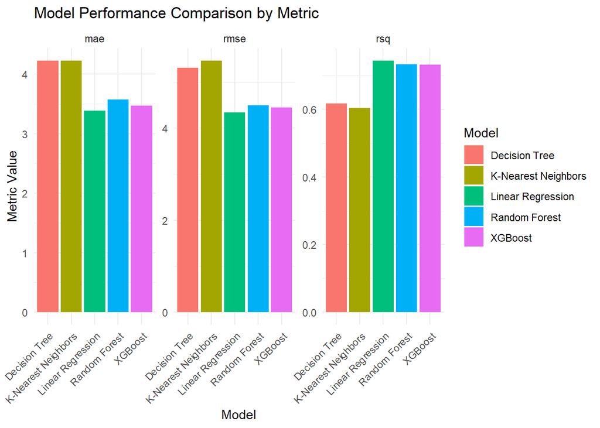

```r
ggplot(bootstrap_results, aes(x = workflow_names, y = mean, fill = workflow_names)) +
  geom_bar(stat = "identity", position = position_dodge()) +
  facet_wrap(~ .metric, scales = "free") +
  labs(title = "Model Performance Comparison by Metric",
       x = "Model",
       y = "Metric Value",
       fill = "Model") +
  theme_minimal() +
  theme(axis.text.x = element_text(angle = 45, hjust = 1))
```

We can see that linear regression model gives us the least mae and rmse and highest rsq compared to other models, the linear model fits well to the taining data.

### Testing

Lets Evaluate the predictive performance on the held-out test data.

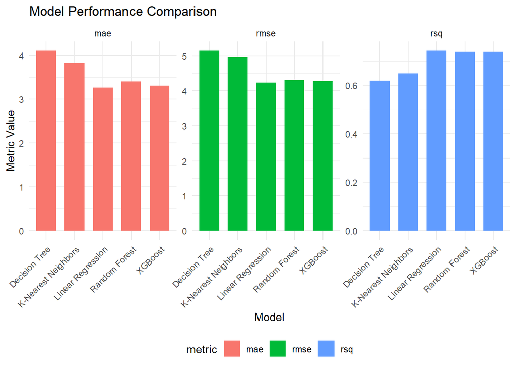

```r
workflows_tbl_test_predictions <- workflows_tbl |>
  mutate(test_pred_value = list(predict(fits,
                                        test_data)))

predictions_test_data  <- workflows_tbl_test_predictions |>
  dplyr::select(workflow_names,
                test_pred_value) |>
  unnest(cols = c(test_pred_value)) |>
  cbind(actual_health_score_test = test_data |>
          pull(health_score))

model_performance_test_data <- predictions_test_data |>
  group_by(workflow_names) |>
  summarise(
    mae = mean(abs(.pred - actual_health_score_test)),
    rmse = sqrt(mean((
      .pred - actual_health_score_test
    ) ^ 2)),
    rsq = cor(.pred, actual_health_score_test) ^ 2
  )

model_performance_test_data |>
  pivot_longer(
    cols = c(mae, rmse, rsq),
    names_to = "metric",
    values_to = "value"
  ) |>
  ggplot(aes(x = workflow_names, y = value, fill = metric)) +
  geom_col(position = position_dodge(), width = 0.7) +
  facet_wrap( ~ metric, scales = "free_y") +
  labs(title = "Model Performance Comparison",
       x = "Model",
       y = "Metric Value") +
  theme_minimal() +
  theme(axis.text.x = element_text(angle = 45, hjust = 1),
        legend.position = "bottom")
```